# Breathing analysis

2022-05-05

# Breathing rate (cycles per minute)

### Breathing rate was lowest during **speaking**, and the durations of the breathing cycles were the longest also during speaking, which makes sense.

**These effects followed a similar pattern in all conditions (but see more details below)**

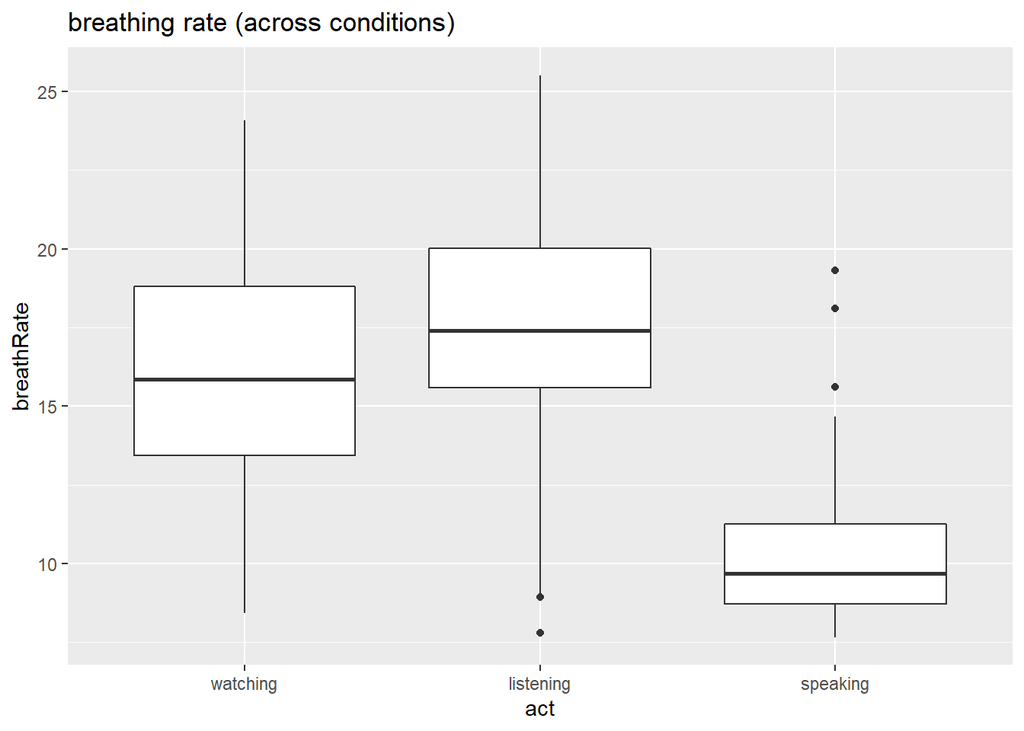

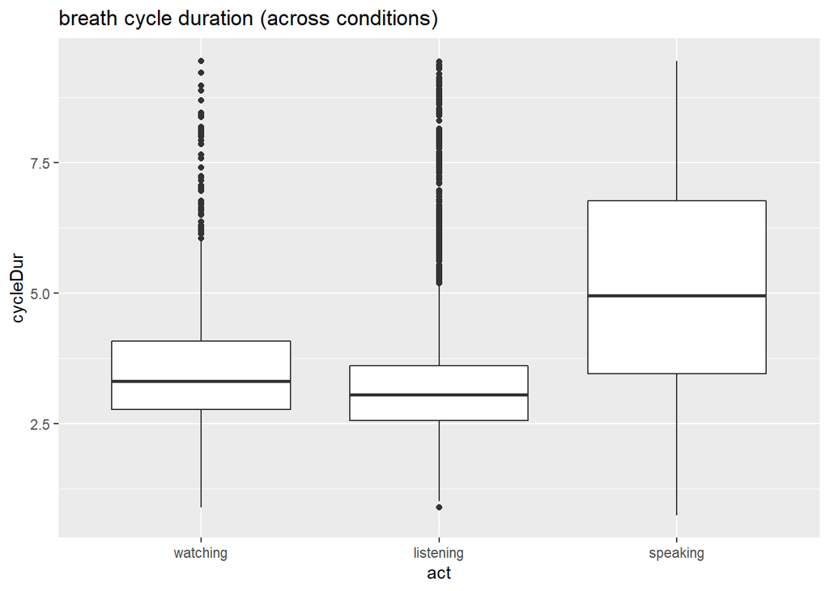

```
## Linear mixed model fit by REML ['lmerMod']
## Formula: breathRate ~ act + (1 | Speaker)
##    Data: br %>% filter(Role == "Participant")
##
## REML criterion at convergence: 684
##
## Scaled residuals:
##      Min       1Q   Median       3Q      Max
## -2.46401 -0.60159 -0.01842  0.55095  2.75462
##
## Random effects:
##  Groups   Name        Variance Std.Dev.
##  Speaker  (Intercept) 6.459    2.541
##  Residual             5.583    2.363
## Number of obs: 141, groups:  Speaker, 22
##
## Fixed effects:
##              Estimate Std. Error t value
## (Intercept)   15.8040     0.6299  25.092
## actlistening   1.1277     0.7992   1.411
## actspeaking   -5.4584     0.4285 -12.739
##
## Correlation of Fixed Effects:
##             (Intr) actlst
## actlistenng -0.215
## actspeaking -0.376  0.250
```

```
## Linear mixed model fit by REML ['lmerMod']
## Formula: cycleDur ~ act + (1 | Speaker)
##    Data: OGbr %>% filter(Role == "Participant")
##
## REML criterion at convergence: 19930.9
##
## Scaled residuals:
##     Min      1Q  Median      3Q     Max
## -3.8782 -0.4713 -0.1210  0.3616  4.3309
##
## Random effects:
##  Groups   Name        Variance Std.Dev.
##  Speaker  (Intercept) 0.6104   0.7813
##  Residual             2.0473   1.4308
## Number of obs: 5579, groups:  Speaker, 22
##
## Fixed effects:
##             Estimate Std. Error t value
## (Intercept)  3.56354    0.16884  21.106
## actspeaking  1.72741    0.04467  38.668
## actwatching  0.31297    0.05744   5.448
##
## Correlation of Fixed Effects:
##             (Intr) actspk
## actspeaking -0.097
## actwatching -0.069  0.266
```

### Comparing the conditions, the only effect seemed to have been *speaking alone* vs *speaking with the confederate*

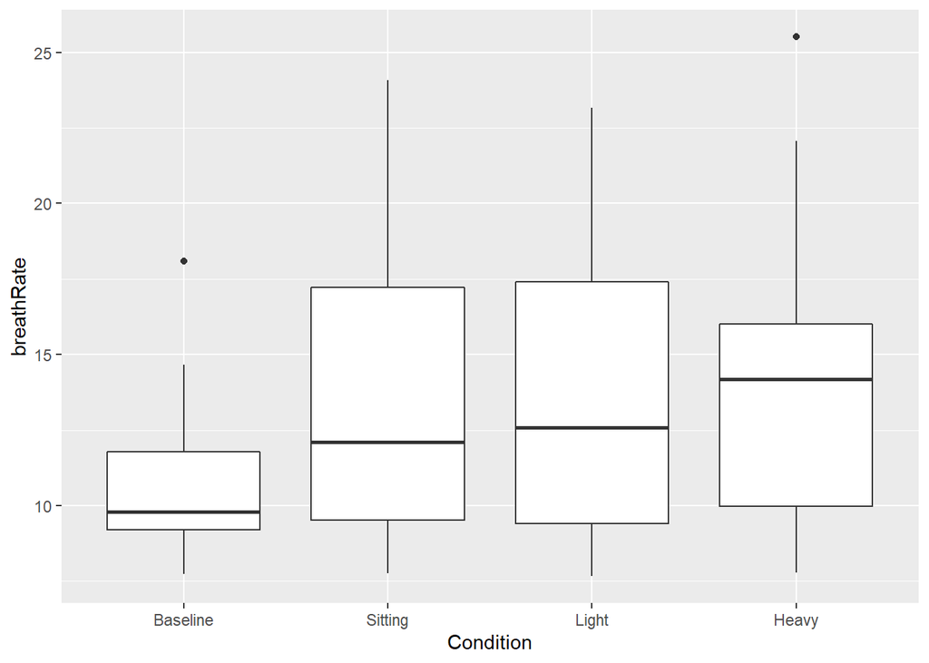

```
## Linear mixed model fit by REML ['lmerMod']
## Formula: breathRate ~ Condition + (1 | Speaker)
##    Data: br %>% filter(Role == "Participant")
##
## REML criterion at convergence: 788.5
##
## Scaled residuals:
##     Min      1Q  Median      3Q     Max
## -2.1501 -0.7096 -0.1328  0.6602  2.3883
##
## Random effects:
##  Groups   Name        Variance Std.Dev.
##  Speaker  (Intercept)  6.634   2.576
##  Residual             13.437   3.666
## Number of obs: 141, groups:  Speaker, 22
##
## Fixed effects:
##                   Estimate Std. Error t value
## (Intercept)        13.2031     0.7954  16.600
## ConditionBaseline  -2.3001     1.0433  -2.205
## ConditionHeavy      0.5223     0.8070   0.647
## ConditionLight      0.3717     0.8153   0.456
##
## Correlation of Fixed Effects:
##             (Intr) CndtnB CndtnH
## ConditnBsln -0.394
## ConditinHvy -0.514  0.386
## ConditnLght -0.506  0.385  0.498
```

### Following Paccalin & Jeannerod, we’d expect a difference between sitting, light biking and heavy biking when the participants are just watching the confederate and both people are in silence.

### We did **not** replicate this effect.

**This could potentially be because our recordings of this “watching” period were a bit short (< 1 min; P&J did 1-min recordings).** **The heavy biking condition seems to have had less variability in breathing rate. I don’t know how significant that is.**

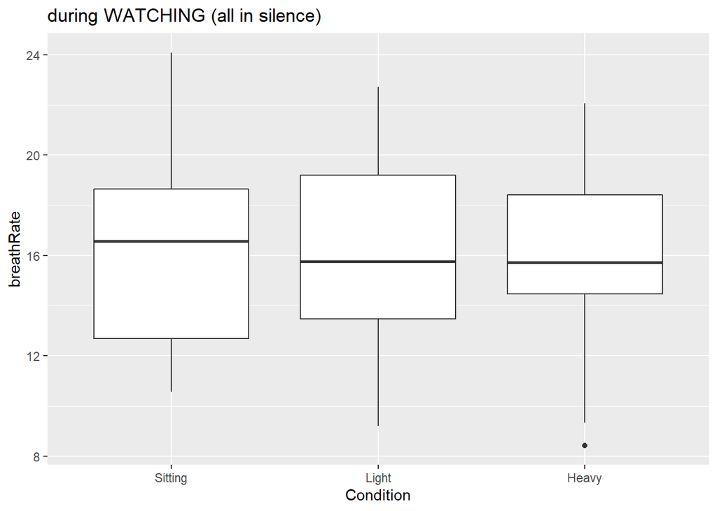

```
## Linear mixed model fit by REML ['lmerMod']
## Formula: breathRate ~ Condition + (1 | Speaker)
##    Data: br %>% filter(Role == "Participant") %>% filter(act == "watching")
##
## REML criterion at convergence: 282.1
##
## Scaled residuals:
##      Min       1Q   Median       3Q      Max
## -2.07664 -0.41767  0.03039  0.42510  2.25660
##
## Random effects:
##  Groups   Name        Variance Std.Dev.
##  Speaker  (Intercept) 11.456   3.385
##  Residual              4.281   2.069
## Number of obs: 57, groups:  Speaker, 21
##
## Fixed effects:
##                Estimate Std. Error t value
## (Intercept)    16.17562    0.88687  18.239
## ConditionHeavy -0.65155    0.67941  -0.959
## ConditionLight -0.09124    0.68439  -0.133
##
## Correlation of Fixed Effects:
##             (Intr) CndtnH
## ConditinHvy -0.402
## ConditnLght -0.371  0.484
```

### During **listening**, there seems to be a difference in breathing rates, but the regression doesn’t support this.

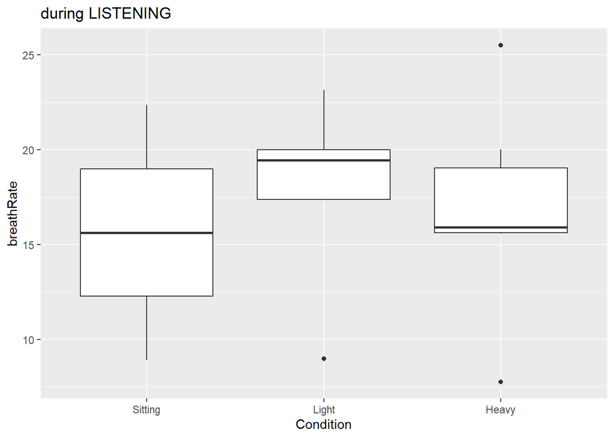

```
## Linear mixed model fit by REML ['lmerMod']
## Formula: breathRate ~ Condition + (1 | Speaker)
##    Data: br %>% filter(Role == "Participant") %>% filter(act == "listening")
##
## REML criterion at convergence: 59.7
##
## Scaled residuals:
##      Min       1Q   Median       3Q      Max
## -0.53167 -0.30176 -0.03183  0.13190  0.92501
##
## Random effects:
##  Groups   Name        Variance Std.Dev.
##  Speaker  (Intercept) 26.9809  5.1943
##  Residual              0.8887  0.9427
## Number of obs: 13, groups:  Speaker, 9
##
## Fixed effects:
##                Estimate Std. Error t value
## (Intercept)     14.7024     1.9382   7.586
## ConditionHeavy   2.0015     1.0733   1.865
## ConditionLight   0.8436     0.9075   0.929
##
## Correlation of Fixed Effects:
##             (Intr) CndtnH
## ConditinHvy -0.402
## ConditnLght -0.354  0.608
```

### During **speaking**, there is the same trend as during listening, but reduced in intensity (which makes sense: the effect of watching someone bike should be reduced if you’re also engaging your respiratory system to speak).

**The difference between *speaking alone* and *speaking with confederate* shows in the regression if we exclude the breath rates with SD >1.5.**

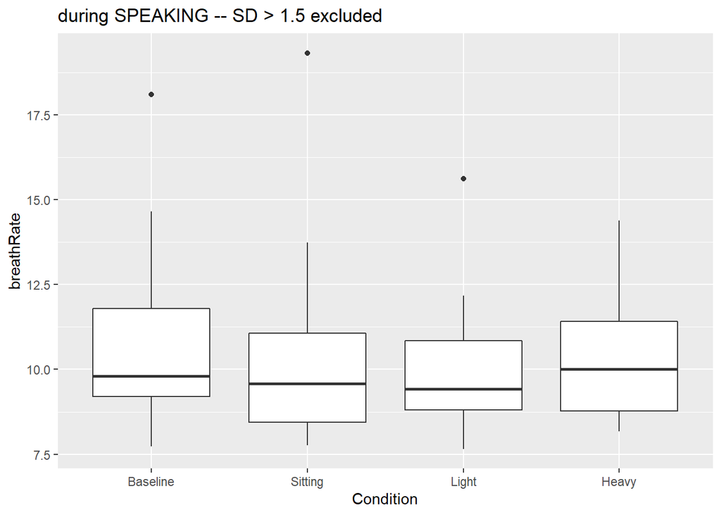

```
## Linear mixed model fit by REML ['lmerMod']
## Formula: breathRate ~ Condition + (1 | Speaker)
##    Data:
## br %>% filter(Role == "Participant") %>% filter(act == "speaking") %>%
##     filter(breathRate < 17.5)
##
## REML criterion at convergence: 223.2
##
## Scaled residuals:
##     Min      1Q  Median      3Q     Max
## -1.4978 -0.5499 -0.0616  0.5499  2.7276
##
## Random effects:
##  Groups   Name        Variance Std.Dev.
##  Speaker  (Intercept) 2.6314   1.6222
##  Residual             0.6954   0.8339
## Number of obs: 69, groups:  Speaker, 21
##
## Fixed effects:
##                   Estimate Std. Error t value
## (Intercept)        9.65537    0.40507  23.836
## ConditionBaseline  0.69532    0.28395   2.449
## ConditionHeavy     0.28477    0.29615   0.962
## ConditionLight     0.07975    0.28129   0.284
##
## Correlation of Fixed Effects:
##             (Intr) CndtnB CndtnH
## ConditnBsln -0.327
## ConditinHvy -0.331  0.441
## ConditnLght -0.321  0.454  0.447
```

# Duration of breath cycles

## Confederate

### In the confederate, we see the expected change in breath cycle duration per condition (but in the regression there was no light vs heavy difference, although the (tendency to the) expeceted pattern still holds).

*Referece level of regression below: light biking*

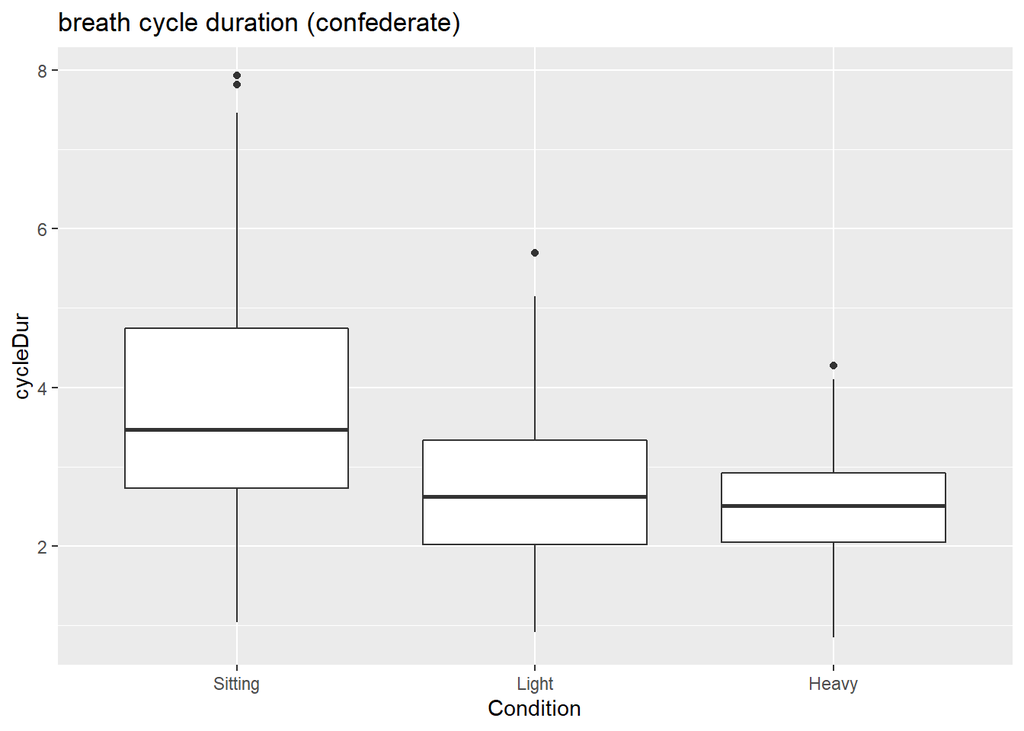

```
##
## Call:
## lm(formula = cycleDur ~ Condition, data = br %>% filter(Role ==
##     "Confederate"))
##
## Residuals:
##     Min      1Q  Median      3Q     Max
## -2.7906 -0.6674 -0.0674  0.5886  4.1003
##
## Coefficients:
##                  Estimate Std. Error t value Pr(>|t|)
## (Intercept)       2.65808    0.07732  34.379   <2e-16 ***
## ConditionHeavy   -0.17484    0.11338  -1.542    0.124
## ConditionSitting  1.17603    0.12135   9.692   <2e-16 ***
## ---
## Signif. codes:  0 '***' 0.001 '**' 0.01 '*' 0.05 '.' 0.1 ' ' 1
##
## Residual standard error: 1.091 on 505 degrees of freedom
## Multiple R-squared:  0.2106, Adjusted R-squared:  0.2075
## F-statistic: 67.36 on 2 and 505 DF,  p-value: < 2.2e-16
```

## Participants

### As expected, during *speaking* there are the longest durations of breathing cycles. But also the most variable durations: it makes sense because people produce utterances of different types and lengths. During watching and listening, the only (? or at least primary) constraint on breathing is the necessity for oxygen, so the breath cycles can be more similar to each other.

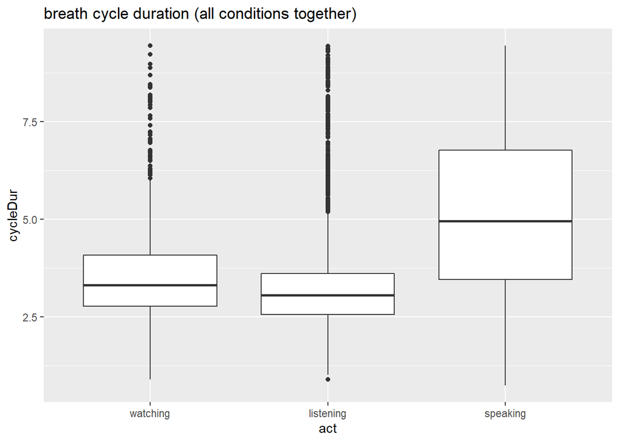

```
## Linear mixed model fit by REML ['lmerMod']
## Formula: cycleDur ~ act + (1 | Speaker)
##    Data: br %>% filter(Role == "Participant")
##
## REML criterion at convergence: 19930.9
##
## Scaled residuals:
##     Min      1Q  Median      3Q     Max
## -3.8782 -0.4713 -0.1210  0.3616  4.3309
##
## Random effects:
##  Groups   Name        Variance Std.Dev.
##  Speaker  (Intercept) 0.6104   0.7813
##  Residual             2.0473   1.4308
## Number of obs: 5579, groups:  Speaker, 22
##
## Fixed effects:
##              Estimate Std. Error t value
## (Intercept)   3.87651    0.17458  22.205
## actlistening -0.31297    0.05744  -5.448
## actspeaking   1.41444    0.06268  22.567
##
## Correlation of Fixed Effects:
##             (Intr) actlst
## actlistenng -0.263
## actspeaking -0.245  0.727
```

### Listening has slightly **shorter** cycle durations than during just watching. This is different from previous studies that found that breathing during listening looked like something in-between silent breathing and speech breathing.

**The listening < watching effect happened in all conditions, but slightly more so during biking than during sitting.**

**I’m not sure what to make of this in terms of theory.**

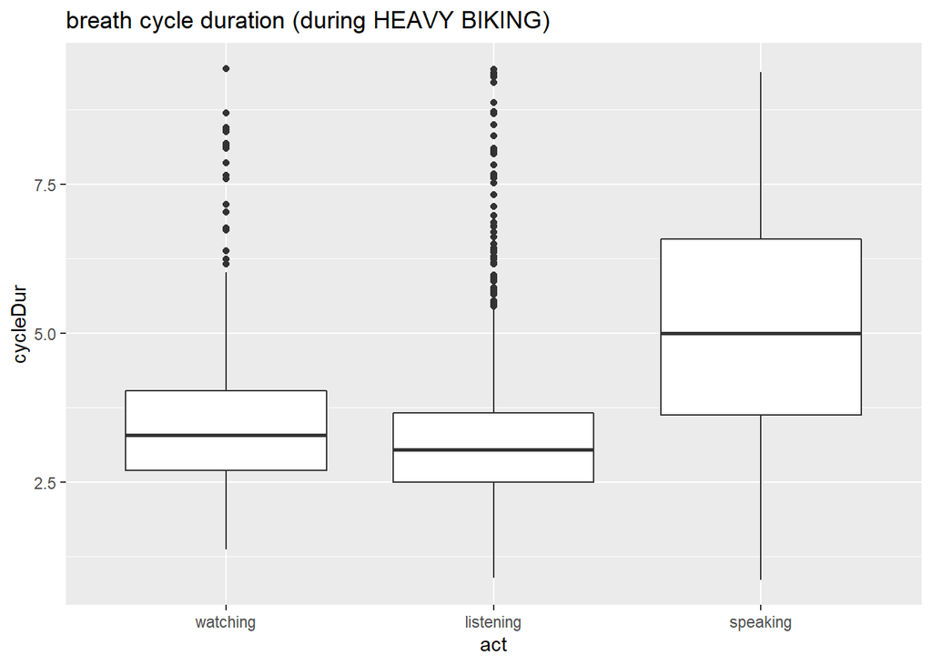

```
## Linear mixed model fit by REML ['lmerMod']
## Formula: cycleDur ~ act + (1 | Speaker)
##    Data: br %>% filter(Role == "Participant") %>% filter(Condition ==
##     "Heavy")
##
## REML criterion at convergence: 5236.7
##
## Scaled residuals:
##     Min      1Q  Median      3Q     Max
## -3.6936 -0.4788 -0.1380  0.3602  4.3423
##
## Random effects:
##  Groups   Name        Variance Std.Dev.
##  Speaker  (Intercept) 0.6154   0.7844
##  Residual             1.9345   1.3909
## Number of obs: 1477, groups:  Speaker, 22
##
## Fixed effects:
##              Estimate Std. Error t value
## (Intercept)   3.82481    0.18872  20.267
## actlistening -0.30686    0.09806  -3.129
## actspeaking   1.46746    0.11449  12.817
##
## Correlation of Fixed Effects:
##             (Intr) actlst
## actlistenng -0.392
## actspeaking -0.330  0.634
```

# Number of IPUs per breathing cycle

## Confederate

### When biking, the confederate seems to produce slightly fewer IPUs per breath cycle (which makes sense! We have less breath available when biking).

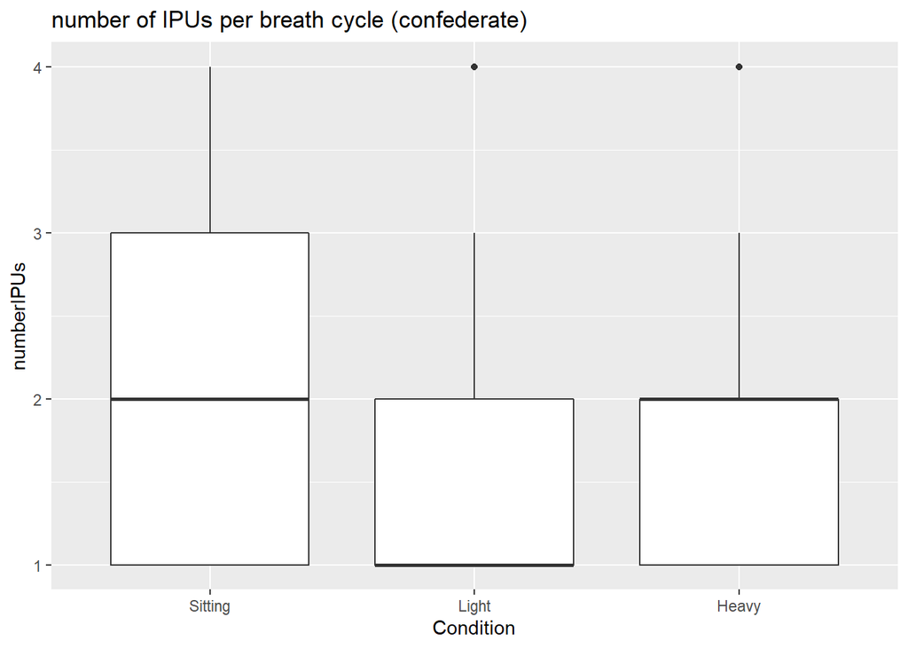

```
##
## Call:
## lm(formula = numberIPUs ~ Condition, data = br %>% filter(Role ==
##     "Confederate"))
##
## Residuals:
##     Min      1Q  Median      3Q     Max
## -0.8897 -0.6416  0.1103  0.4121  2.4121
##
## Coefficients:
##                Estimate Std. Error t value Pr(>|t|)
## (Intercept)     1.88971    0.06602  28.624  < 2e-16 ***
## ConditionLight -0.30177    0.08566  -3.523 0.000465 ***
## ConditionHeavy -0.24809    0.08823  -2.812 0.005118 **
## ---
## Signif. codes:  0 '***' 0.001 '**' 0.01 '*' 0.05 '.' 0.1 ' ' 1
##
## Residual standard error: 0.7699 on 505 degrees of freedom
## Multiple R-squared:  0.0257, Adjusted R-squared:  0.02185
## F-statistic: 6.662 on 2 and 505 DF,  p-value: 0.001394
```

## Participants

### Participants really don’t seem to change their IPUs per cycle across conditions

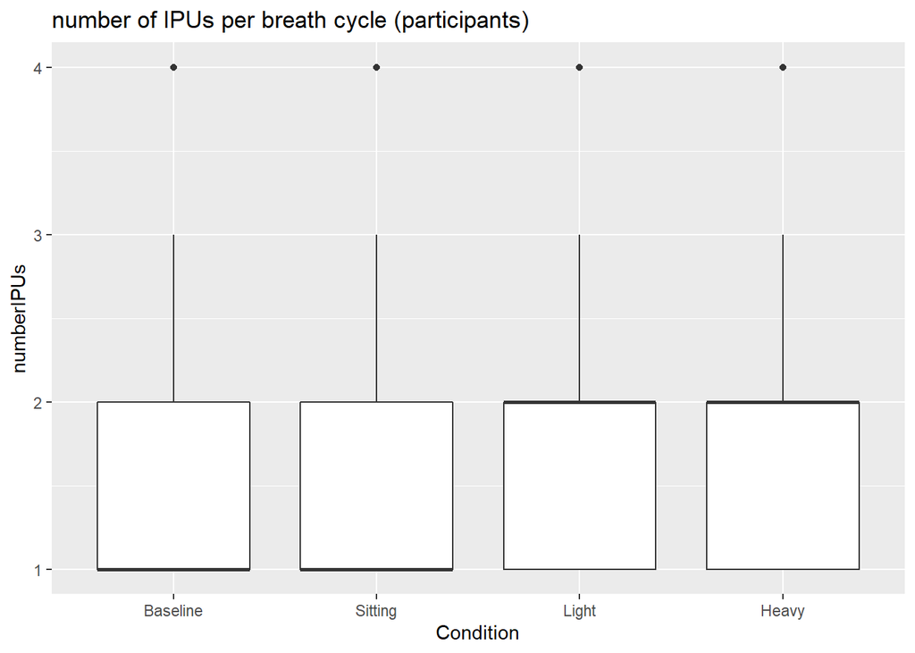

```
## Linear mixed model fit by REML ['lmerMod']
## Formula: numberIPUs ~ Condition + (1 | Speaker)
##    Data: br %>% filter(Role == "Participant")
##
## REML criterion at convergence: 4364.1
##
## Scaled residuals:
##     Min      1Q  Median      3Q     Max
## -1.2650 -0.8413 -0.3351  0.4930  3.1420
##
## Random effects:
##  Groups   Name        Variance Std.Dev.
##  Speaker  (Intercept) 0.05166  0.2273
##  Residual             0.67852  0.8237
## Number of obs: 1760, groups:  Speaker, 21
##
## Fixed effects:
##                   Estimate Std. Error t value
## (Intercept)        1.71262    0.06322  27.089
## ConditionLight     0.05799    0.05679   1.021
## ConditionBaseline  0.03449    0.05450   0.633
## ConditionHeavy     0.04554    0.05809   0.784
##
## Correlation of Fixed Effects:
##             (Intr) CndtnL CndtnB
## ConditnLght -0.405
## ConditnBsln -0.418  0.463
## ConditinHvy -0.398  0.466  0.439
```